# Residual diagnostics

Matthew Rudd

2/8/2022

# Compressive strength of concrete

## What is concrete?

Concrete is a common building material. Its strength depends on how much water and cement are used to make it; specifically, the ratio of cement to water has a profound influence on its compressive strength.

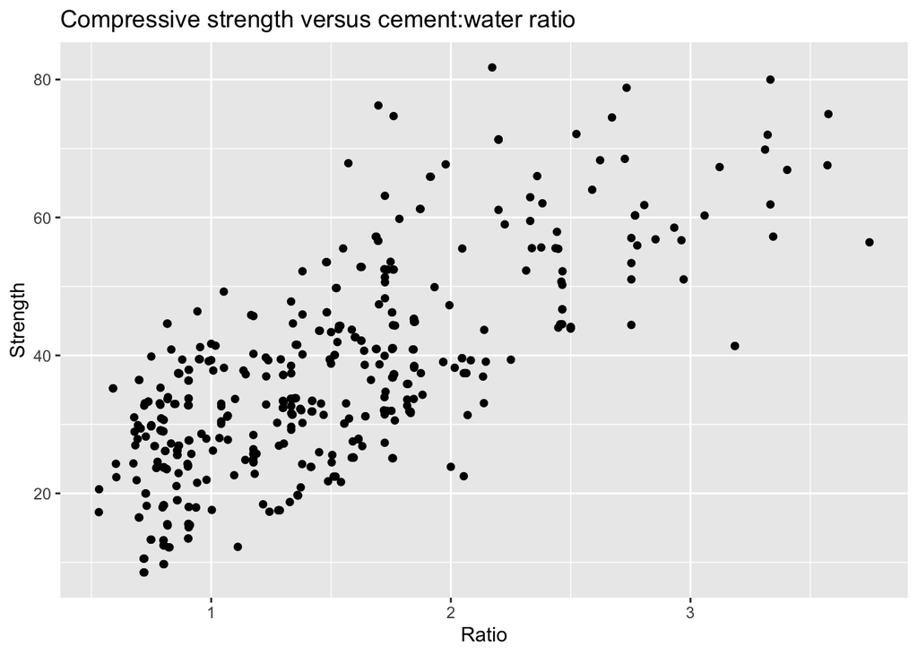

We can see a positive linear relationship here. The correlation coefficient corroborates this:

```r
cor( concrete$Ratio, concrete$Strength)
```

```
## [1] 0.7251376
```

## Simple regression model

### Fit the model

Having checked the scatterplot and the correlation coefficient, it seems reasonable to fit a simple linear regression model to this data. Here it is:

```r
concrete.fit <- lm( Strength ~ Ratio, data = concrete )
summary(concrete.fit)
```

```
##
## Call:
## lm(formula = Strength ~ Ratio, data = concrete)
##
## Residuals:
##     Min      1Q  Median      3Q     Max
## -23.618  -7.576  -0.686   6.503  35.942
##
## Coefficients:
##             Estimate Std. Error t value Pr(>|t|)
## (Intercept)  12.5968     1.2188   10.34   <2e-16 ***
## Ratio        16.3158     0.7533   21.66   <2e-16 ***
## ---
## Signif. codes:  0 '***' 0.001 '**' 0.01 '*' 0.05 '.' 0.1 ' ' 1
##
## Residual standard error: 10.14 on 423 degrees of freedom
## Multiple R-squared:  0.5258, Adjusted R-squared:  0.5247
## F-statistic: 469.1 on 1 and 423 DF,  p-value: < 2.2e-16
```

The fitted model is therefore
$$\text{Strength} ~ = ~ 12.5968 + 16.3158 \times \text{Ratio} \ ,$$
where `Strength` has units of megapascals (MPa).

*If the error term in the theoretical model is normally distributed*, $\epsilon \sim N(0,\sigma)$, then we can combine the point estimates (the coefficients) with their given standard errors to get confidence intervals for the parameters in the theoretical model; the function `confint` takes care of the calculations.

```r
confint( concrete.fit )
```

```
##                2.5 %   97.5 %
## (Intercept) 10.20107 14.99251
## Ratio       14.83506 17.79654
```

If we trust the normality assumption, then we are 95% confident that the “true slope” $\beta$ – the slope in the theoretical model – is between 14.83506 and 17.79654.

*This approach to inferences relies on normality of the errors, which we have to check!!* If the errors don’t seem to be normally distributed, a resampling method (the *bootstrap*) can be used to draw inferences about the parameters in the theoretical model. In fact, bootstrapping should always be used for such inferences, even if the errors seem roughly normally distributed. We’ll talk about that tool later.

### Histogram and plot of residuals

The residuals for the fitted model are our best estimates of the errors, so we need to analyze the residuals to determine whether the errors seem to be roughly normally distributed. As a first check, just look at a histogram of the residuals:

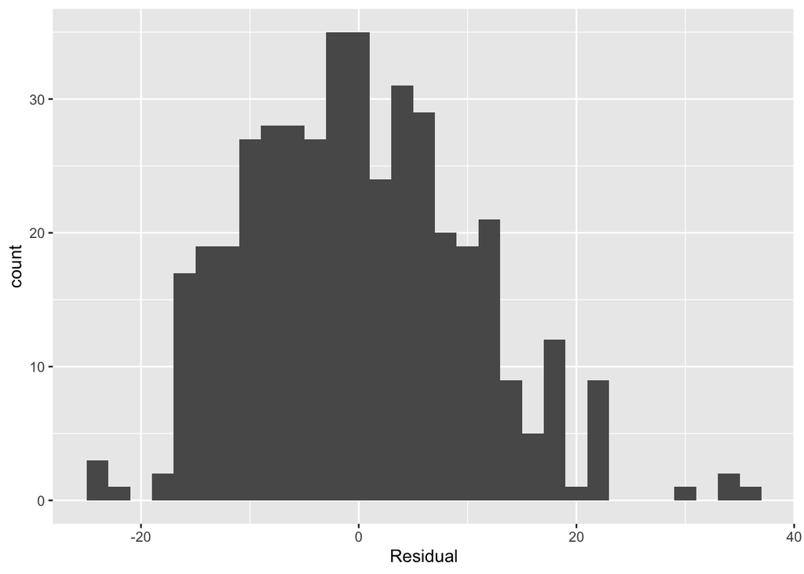

```r
concrete <- concrete %>%
  mutate( Prediction = concrete.fit$fitted.values,
          Residual = concrete.fit$residuals )

ggplot( concrete, aes(Residual)) +
  geom_histogram( binwidth=2)
```

That doesn’t seem horribly _non_normal – the histogram seems roughly symmetric and bell-shaped. Next, let’s plot the residuals versus the fitted values (predictions) to see if there are any noticeable patterns or trends:

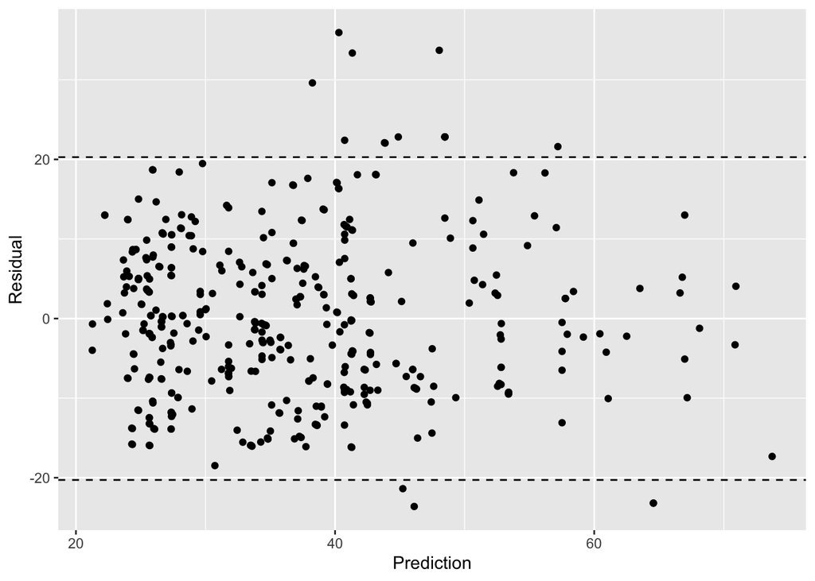

```r
ggplot( concrete, aes(Prediction, Residual)) +
  geom_point() +
  geom_hline( yintercept = c(-2,2)*sigma(concrete.fit), linetype="dashed")
```

The vast majority of the residuals are within 2 RSEs of 0, which provides more evidence of (a) no serious departure from normality and (b) homoscedasticity. The 3 residuals at the top (magnitude greater than 30) are a bit worrying, but not enough to throw in the towel. Note that  
the residuals seem to be randomly distributed about 0, which is good.

### Quantiles of residuals

To quantify some of this, let’s compare the quantiles of the *standardized residuals* (residuals divided by the RSE) with those of the standard normal distribution. If the residuals are roughly normally distributed, their quantiles ought to match fairly well with those of $N(0,1)$.

```r
quantile( concrete.fit$residuals / sigma( concrete.fit ), probs=seq(0,1,by=.25))
```

```
##          0%         25%         50%         75%        100%
## -2.32866170 -0.74699480 -0.06762696  0.64116759  3.54381889
```

```r
qnorm( c(.001, .25, .5, .75, .999 ) )
```

```
## [1] -3.0902323 -0.6744898  0.0000000  0.6744898  3.0902323
```

Instead of just looking at a few quantiles, let’s compare more of them visually; we’re looking to see if the plotted quantiles fall on the line shown:

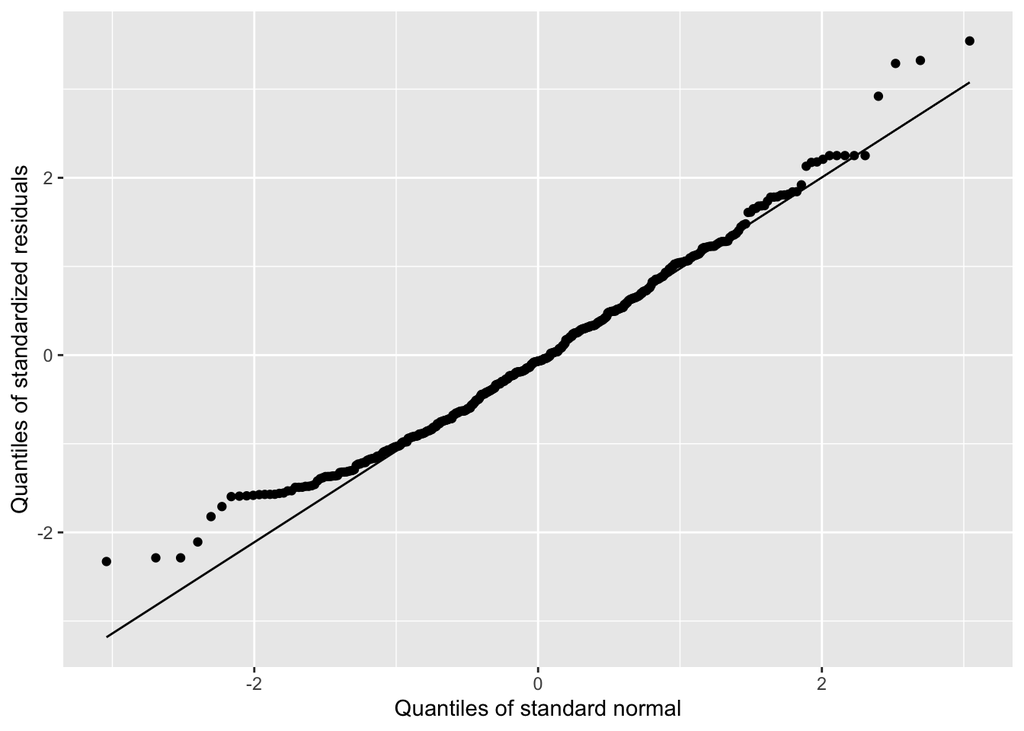

```r
ggplot( concrete, aes(sample=Residual/sigma(concrete.fit))) +
  stat_qq() +
  stat_qq_line() +
  labs( x = "Quantiles of standard normal",
        y = "Quantiles of standardized residuals" )
```

There are some deviations in the extremes (not a surprise), but most of the quantiles line up nicely. So far, so good!

### Statistical tests for normality

There are a gajillion tests for normality, including:

- Shapiro-Wilk test
- Anderson-Darling test
- Kolmogorov-Smirnov test
- Lilliefors test

As an example, let’s apply the Shapiro-Wilk test, which is very commonly used:

```r
shapiro.test(concrete$Residual)
```

```
##
##  Shapiro-Wilk normality test
##
## data:  concrete$Residual
## W = 0.9848, p-value = 0.0001961
```

To interpret this output, first recall how every statistical test works: assuming that some hypothesis – namely, the *null hypothesis* – is true,

- compute the relevant test statistic, then
- compute the probability of obtaining a test statistic this large or larger in magnitude.

The probability thus obtained is the $p$-value; colloquially, the $p$-value is the *chance of getting what you got* *if the null hypothesis is true*.

In this particular example, the null hypothesis says that the residuals for our linear regression model are normally distributed. The value of the test statistic is $W = 0.9848$, and the $p$-value of 0.0001961 tells us that obtaining this value of $W$ is very unlikely if the null hypothesis is true. Hmmm. Does this mean that all the work we just did to check normality is useless? Absolutely not!! Our preceding visual analyses (histogram, plot of residuals versus fitted values, $qq$-plot) suggest that the residuals are indeed *roughly* normally distributed, with some deviations from normality in the extreme residuals; we didn’t claim that the residuals were *exactly* normally distributed, as the null hypothesis asserts. Those deviations in the tails and the number of residuals together lead to this $W$-score, its small $p$-value, and the rejection of the null hypothesis via this test.

The main point here is that statistical tests are just one part of our diagnostic arsenal; we need to use a variety of complementary tools to draw conclusions. In particular, don’t make decisions based on $p$-values alone!